# Maine Coastal Current Indicators of Habitat and Ecosystem Change

Matt Dzaugis

2022-01-12

```r
# Indicators
allIndicators <- read_csv(here::here("Processed_Indicators/allIndicators.csv"))
allIndicators$Season <- factor(allIndicators$Season, levels= c("spring", "summer", "fall", "winter", "all"))
allIndicators$stat_area <- factor(allIndicators$stat_area, levels= c("511", "512", "513", "511-513"))
indicators <- unique(allIndicators$Indicator)

# Enter indicator, season, stat area of interest

indicator_sel <- "stratification"
season_sel <- "all"
stat_areas_sel <- "511-513"

# Enter the npsi (estimated number of breakpoints) - might need to run the code first and assess the breakpoint stats
Npsi <- 1 # estimated number of breakpoints
# enter a list of models for the mean breakpoint - a model of 1~1 indicates intercept, adding additional models incudes additional bp
model_list <- list(Value~1, 1~1)
```

```r
plot_fun <- function(x, indicator){
  x %>%
    filter(Indicator == indicator) %>%
    ggplot() +
    geom_line(aes(Year, Value, col = stat_area)) +
    theme_bw() +
    facet_wrap(~Season)
}

sumLms_fun <- function(indicator, season, stat_areas){
  df <- allIndicators %>%
    filter(Indicator == indicator,
           Season == season,
           stat_area == stat_areas)

  lm1 <- lm(Value ~ Year, data = df)
  return(lm1)
}


acf_plot <- function(indicator, season, stat_areas){
    df <- allIndicators %>%
    filter(Indicator == indicator,
           Season == season,
           stat_area == stat_areas) %>%
      select(Year, Value)
  acf(df)
}

pscore_fun <- function(indicator, season, stat_areas){
  df <- allIndicators %>%
    filter(Indicator == indicator,
           Season == season,
           stat_area == stat_areas)

  lm1 <- lm(Value ~ Year, data = df)
  pscore <- segmented::pscore.test(lm1)
  return(pscore)
}

davies_fun <- function(indicator, season, stat_areas){
  df <- allIndicators %>%
    filter(Indicator == indicator,
           Season == season,
           stat_area == stat_areas)

  lm1 <- lm(Value ~ Year, data = df)
  davies <- segmented::davies.test(lm1)
  return(davies)
}

slope_bp_fun <- function(indicator, season, stat_areas, Npsi){
    df <- allIndicators %>%
    filter(Indicator == indicator,
           Season == season,
           stat_area == stat_areas)

  lm1 <- lm(Value ~ Year, data = df)

  segmented::segmented(lm1, seg.Z = ~Year, npsi = Npsi)
}

mean_bp_fun <- function(indicator, season, stat_areas, models){
    df <- allIndicators %>%
    filter(Indicator == indicator,
           Season == season,
           stat_area == stat_areas)

  lm1 <- lm(Value ~ Year, data = df)
  temp_mcp1 <- mcp::mcp(models, data = df, par_x = "Year")
  return(temp_mcp1)
}
```

## Developing Indicators of Habitat and Ecosystem Change in the Gulf of Maine

This report includes the initial analysis of the ecosystem and habitat indicators. Linear regression was used to assess trends over the length of the time series. A trend breakpoint analysis and a mean breakpoint analysis were run on the indicators. A breakpoint found in the slope of the line indicates a change in the trend of the data. A breakpoint in the mean of the date may indicate a regime shift or change of the overall state of the system. These analyses were run seasonally within statistical areas, when available, and as yearly averages across the entire study domain.

## Indicators

#### Time series plots

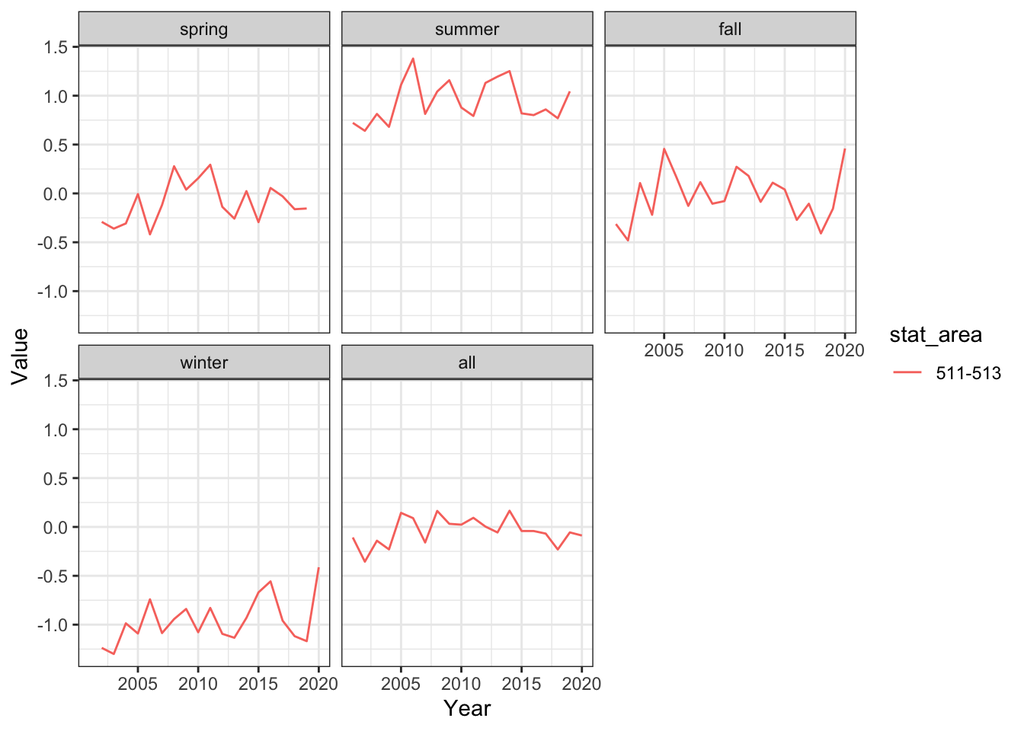

```r
plot_fun(allIndicators, indicator_sel)
```

#### Linear models

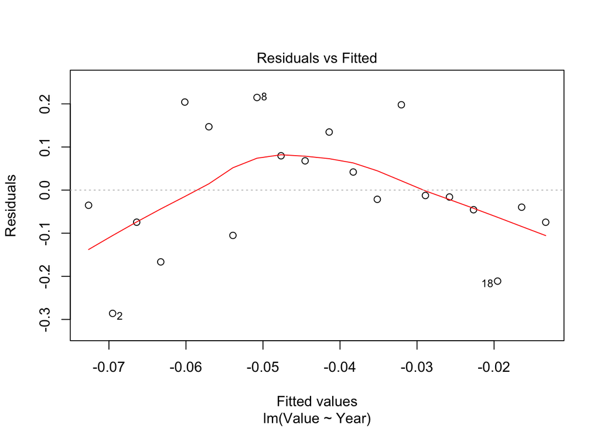

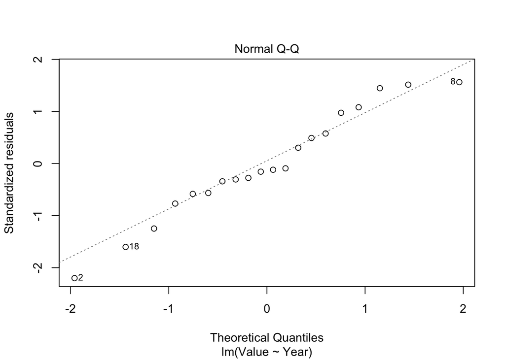

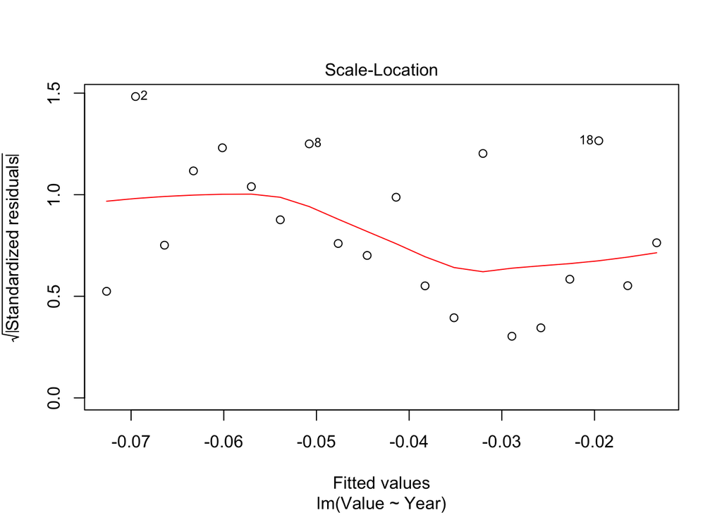

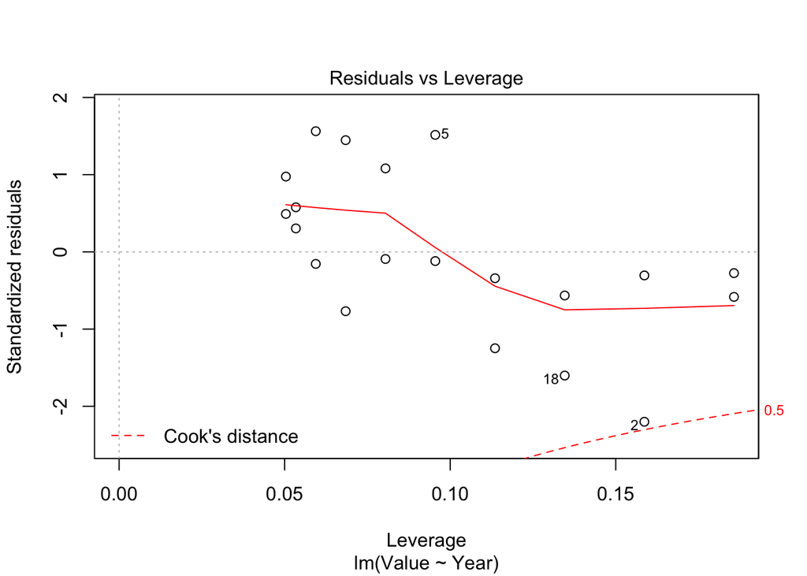

```r
lms <- sumLms_fun(indicator_sel, season_sel, stat_areas_sel)
plot(lms)
```

```r
summary(lms)
```

```
##
## Call:
## lm(formula = Value ~ Year, data = df)
##
## Residuals:
##      Min       1Q   Median       3Q      Max
## -0.28599 -0.07447 -0.01870  0.09337  0.21484
##
## Coefficients:
##              Estimate Std. Error t value Pr(>|t|)
## (Intercept) -6.323234  11.048324  -0.572    0.574
## Year         0.003124   0.005495   0.568    0.577
##
## Residual standard error: 0.1417 on 18 degrees of freedom
## Multiple R-squared:  0.01763,    Adjusted R-squared:  -0.03694
## F-statistic: 0.3231 on 1 and 18 DF,  p-value: 0.5768
```

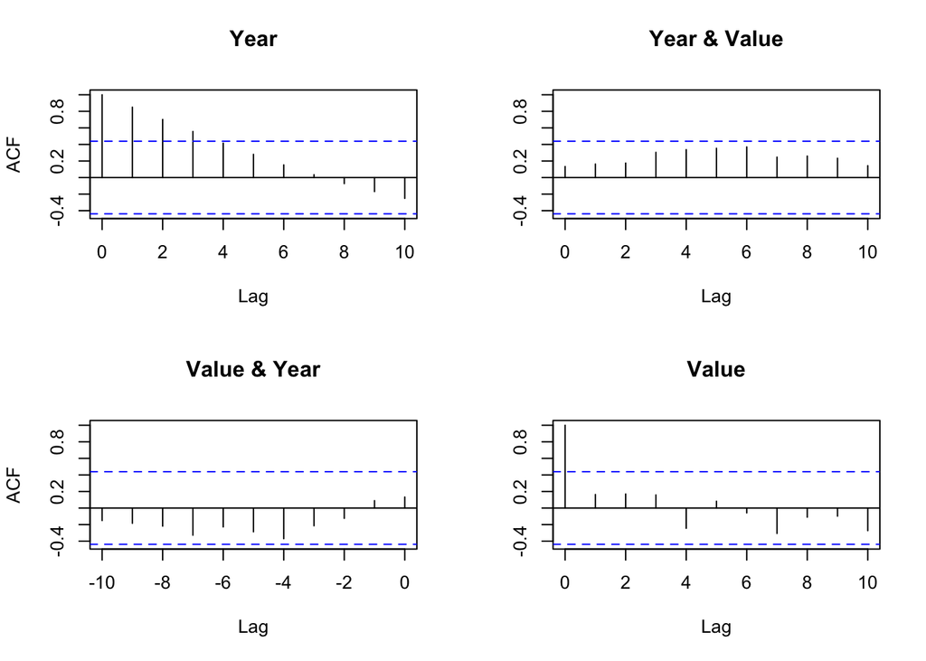

```r
acf_plot(indicator_sel, season_sel, stat_areas_sel)
```

#### Slope breakpoint tests

The pscore test and davies tests indicate whether a breakpoint in the slope exists. The davies test is more sensitive to data that follow a more sinusoidal curve but less sensitive to linear changes. A significant p-value indicates there is a breakpoint in the data. A non-significant p-value indicates a breakpoint is not present.

```r
pscore_fun(indicator_sel, season_sel, stat_areas_sel)
```

```
##
##  Score test for one/two changes in the slope
##
## data:  formula = Value ~ Year
## breakpoint for variable = Year
## model = gaussian , link = identity , method = lm
## observed value = -2.5322, n.points = 10, p-value = 0.02086
## alternative hypothesis: two.sided   (1 breakpoint)
```

```r
davies_fun(indicator_sel, season_sel, stat_areas_sel)
```

```
##
##  Davies' test for a change in the slope
##
## data:  formula = Value ~ Year ,   method = lm
## model = gaussian , link = identity
## segmented variable = Year
## 'best' at = 2007.7, n.points = 10, p-value = 0.04583
## alternative hypothesis: two.sided
```

#### Slope breakpoint

```r
bp <- slope_bp_fun(indicator_sel, season_sel, stat_areas_sel, Npsi)
summary(bp)
```

```
##
##  ***Regression Model with Segmented Relationship(s)***
##
## Call:
## segmented.lm(obj = lm1, seg.Z = ~Year, npsi = Npsi)
##
## Estimated Break-Point(s):
##            Est. St.Err
## psi1.Year 2008  1.644
##
## Meaningful coefficients of the linear terms:
##              Estimate Std. Error t value Pr(>|t|)
## (Intercept) -93.80583   36.36835  -2.579   0.0202 *
## Year          0.04676    0.01814   2.577   0.0203 *
## U1.Year      -0.06378    0.02064  -3.090       NA
## ---
## Signif. codes:  0 '***' 0.001 '**' 0.01 '*' 0.05 '.' 0.1 ' ' 1
##
## Residual standard error: 0.1176 on 16 degrees of freedom
## Multiple R-Squared: 0.3988,  Adjusted R-squared: 0.2861
##
## Convergence attained in 1 iter. (rel. change 4.8526e-08)
```

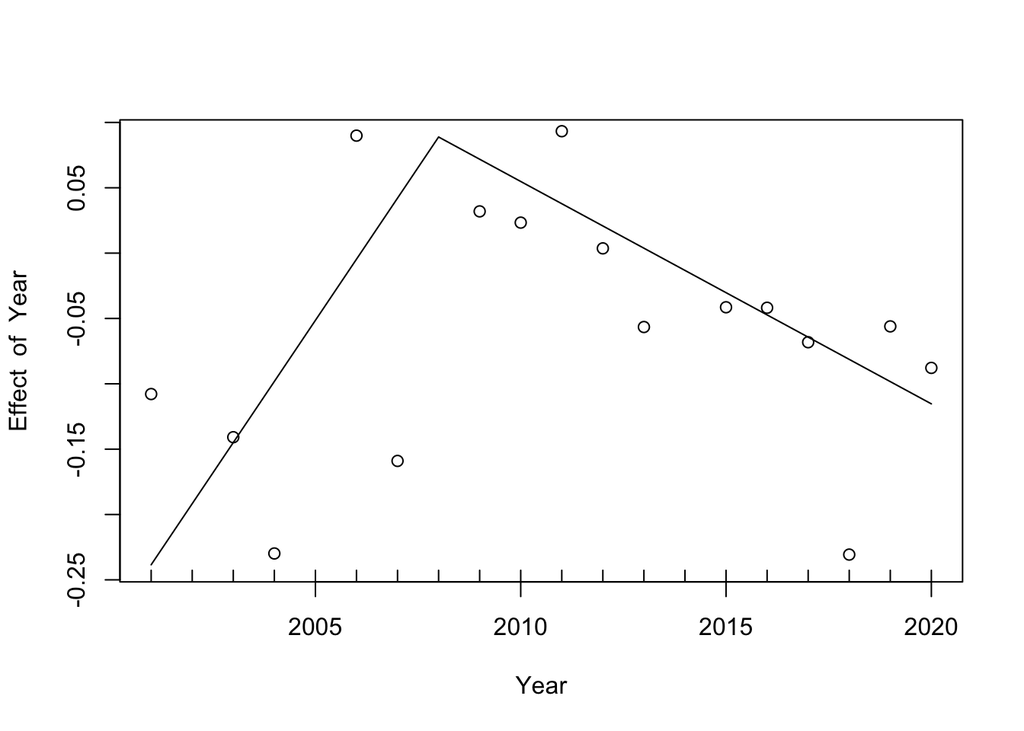

```r
plot(bp)
df <- allIndicators %>%
  filter(Indicator == indicator_sel,
         Season == season_sel,
         stat_area == stat_areas_sel)
points(x = df$Year, y = df$Value)
```

#### Mean breakpoint

```r
mean_cp <- mean_bp_fun(indicator_sel, season_sel, stat_areas_sel, model_list)
summary(mean_cp)
```

```
## Family: gaussian(link = 'identity')
## Iterations: 9000 from 3 chains.
## Segments:
##   1: Value ~ 1
##   2: Value ~ 1 ~ 1
##
## Population-level parameters:
##     name     mean    lower   upper Rhat n.eff
##     cp_1 2005.708 2001.957 2.0e+03    1   149
##    int_1   -0.172   -0.323 7.0e-03    1   434
##    int_2   -0.016   -0.118 7.3e-02    1   664
##  sigma_1    0.127    0.084 1.8e-01    1  1438
```

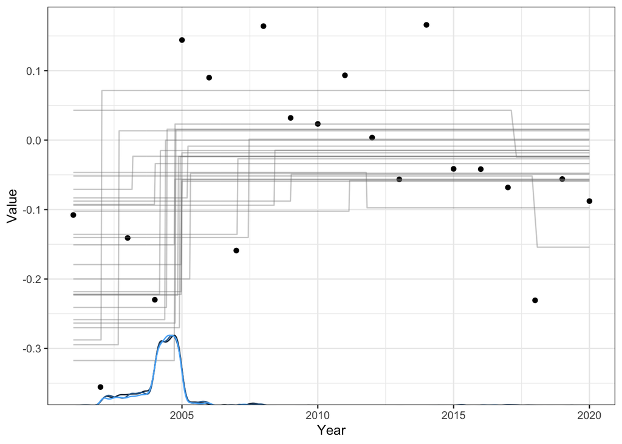

```r
plot(mean_cp)
```